# STA 3100 Programming with Data: Assignment 010

# A Random Angle

If the random variables $X$ and $Y$ are independent and uniformly distributed on the unit interval (the interval from $0$ to $1$), then the ordered pair $(X,Y)$ is uniformly distributed on the unit square $A = \{(x,y) : 0 \le x \le 1, 0 \le y \le 1\}$. Here is an example of a single such point generated in R. (Here I have set the seed for the random number generator so that I get the same result each time this code is run.)

```r
set.seed(324)
X <- runif(1)
Y <- runif(1)
```

With the seed set as above, the point generated is $(X,Y) = (0.7290204, 0.4236485)$. (If you change the seed or remove the `set.seed()` command altogether, then you will get a different point.)

Now consider the random angle $\theta$ between the $x$-axis and the segment joining the origin $(0,0)$ to the point $(X,Y)$. Notice that the tangent of this angle is $Y/X$ (“opposite over adjacent”; see figure), so in our example the observed angle (in degrees) is
$$\theta = \tan^{-1}(0.4236485/0.7290204) = 30.1617392.$$

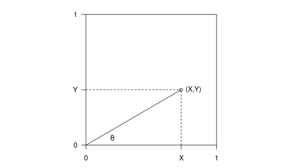

A random point in the unit square.

Suppose that we are interested in the distribution of the random angle $\theta$. It is possible to derive the probability density of $\theta$ mathematically (see STA 4321), but even if we do not know how to do this, we can still approximate the distribution by simulation. To do this, we must draw many random observations from the distribution of $\theta$, or equivalently, we must draw a large number of independent $X$ and $Y$ values from the uniform distribution and calculate the value of theta corresponding to each $(X,Y)$ pair (R’s vectorized functions make this easy). Then the probability of any $\theta$-event can be approximated by calculating the proportion of simulated $\theta$ values for which the event occurs.

# Exercises

1. (10 pts) Calculate 100,000 independent simulated observations of $\theta$ from the random experiment described in the introduction (do not print the values).
2. 1. (5 pts) With the $\theta$ values generated in exercise #1, use the `histogram()` function (with `freq = FALSE`) to graph an estimate of the probability density of $\theta$.

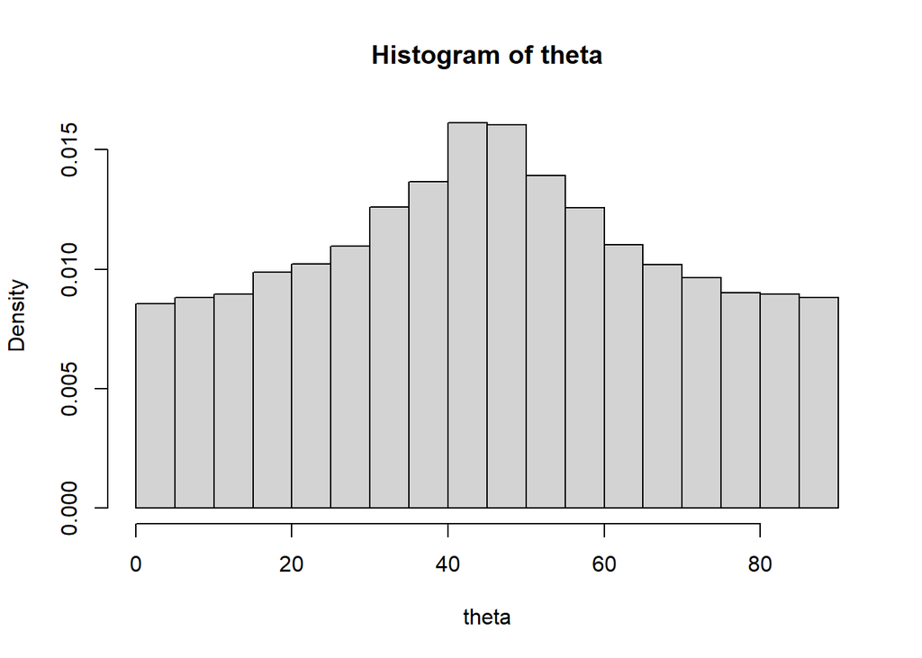

```r
hist(theta, freq = FALSE)
```

2. (5 pts) Based on the histogram, does the distribution appear to be symmetric or is it skewed? Is it unimodal or multimodal or uniform (flat)?

```
Based on the histogram, it would seem that the distribution is both symmetrical and unimodal.
```

3. (5 pts) Based on the histogram, would you say that the angle is uniformly distributed from 0 to 90 degrees, i.e., does it appear that all values between 0 and 90 degrees are equally likely?

[output not shown]

3. Using your simulated values, estimate:
   1. (5 pts) The mean of the distribution of $\theta$.

   The mean of the distribution is 45.0631722
   2. (5 pts) The standard deviation of the distribution.

   The standard deviation of the distribution is 23.784061
   3. (5 pts) The lower quartile, median, and upper quartile of the distribution (use the `quantile()` function for this).

```r
thetaNums <- quantile(theta)
LQ <- thetaNums[2]
median <- thetaNums[3]
UQ <- thetaNums[4]
```

```
The lower quartile of the distribution is 26.6294857

The median fo the distribution is 45.0607616

The upper quartile of the distribution is 63.4016716
```

4. (10 pts) Use your simulated values to estimate the probability that $\theta$ is between 30 and 60 degrees.

```r
thetaSet <- (30 < theta & theta < 60)
prob <- mean(thetaSet) *100
```

```
The probability that 30 < theta < 60 is 42.464 %
```